# practice

Genevieve Housman

Thursday, April 2, 2015

Rmd script that:

1. Loads the data file, selects all the data for Albania+Afghanistan+Algeria, and makes three scatter plots (one for each country) that each have year on the x-axis and GDP on the y-axis. Describe any trends you see for each country using markdown text.

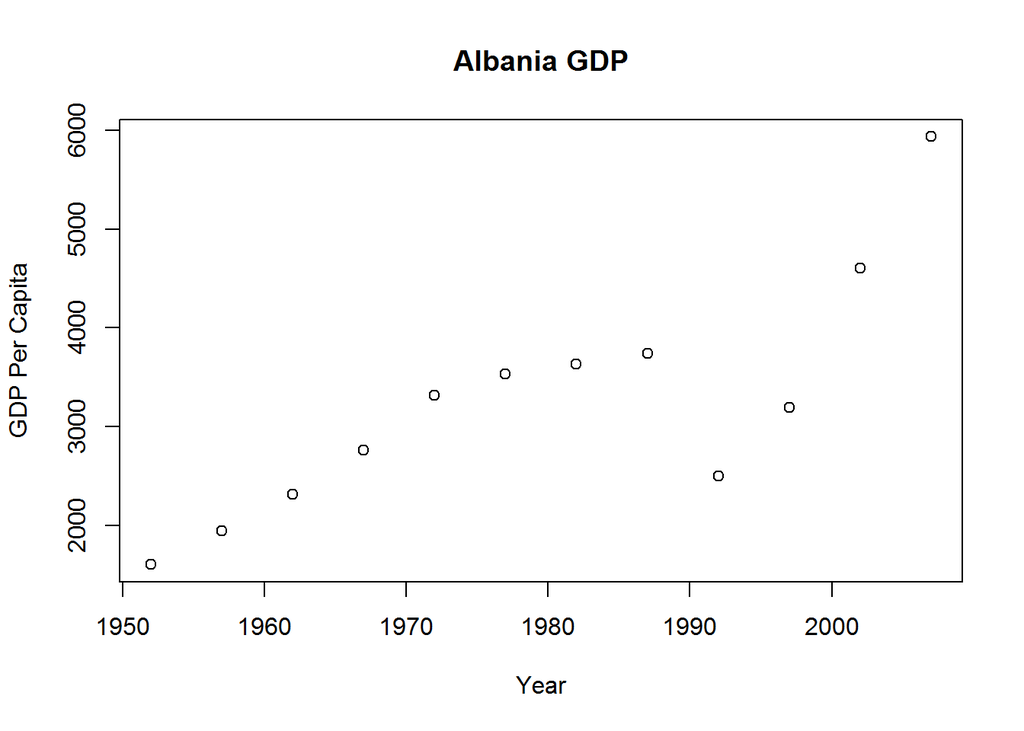

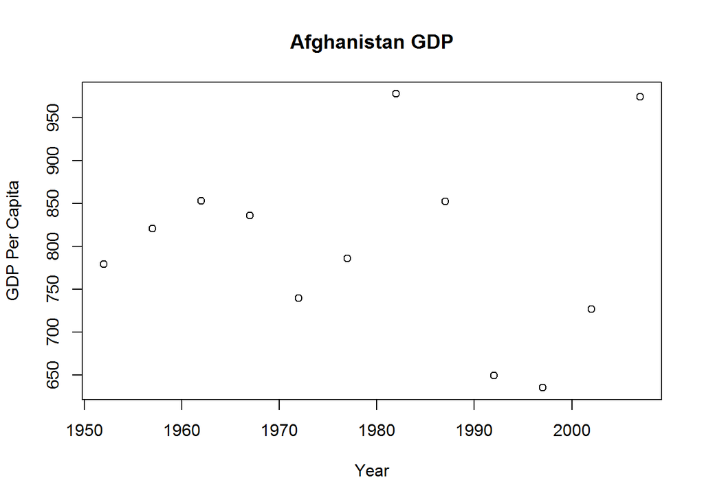

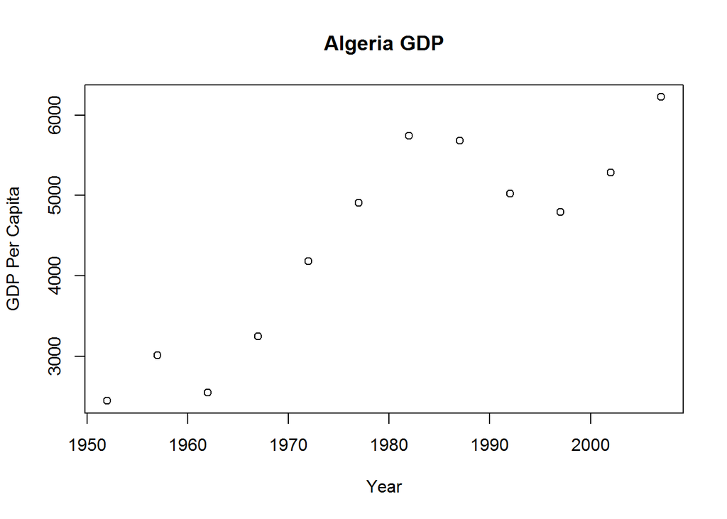

For Albania, the GDP per capita displayed steady linear growth from 1950 to 1990. Then it dropped before displaying a rapid exponential increase until the present. For Afghanistan, the GDP per capita displayed steady linear growth from 1950 until just after 1960. Following this, GDP became highly scattered and random. For Algeria, the GDP per capita displayed rapid linear growth with dips in growth around 1960 and 1985-2000.

2. Calculates the mean, min, and max life expectancies for each continent. Describe what you see in the results using a markdown text.

Albania

[output not shown]

Afghanistan

[output not shown]

Algeria

```
##    Min. 1st Qu.  Median    Mean 3rd Qu.    Max.
##    43.1    50.6    59.7    59.0    68.1    72.3
```

3. Make 2 histograms of global life expectancy. One with the default bin widths and one with narrower bin widths (you can check in help files for the syntax you might need to do this). Explain the differences and any interesting trends in markdown text.

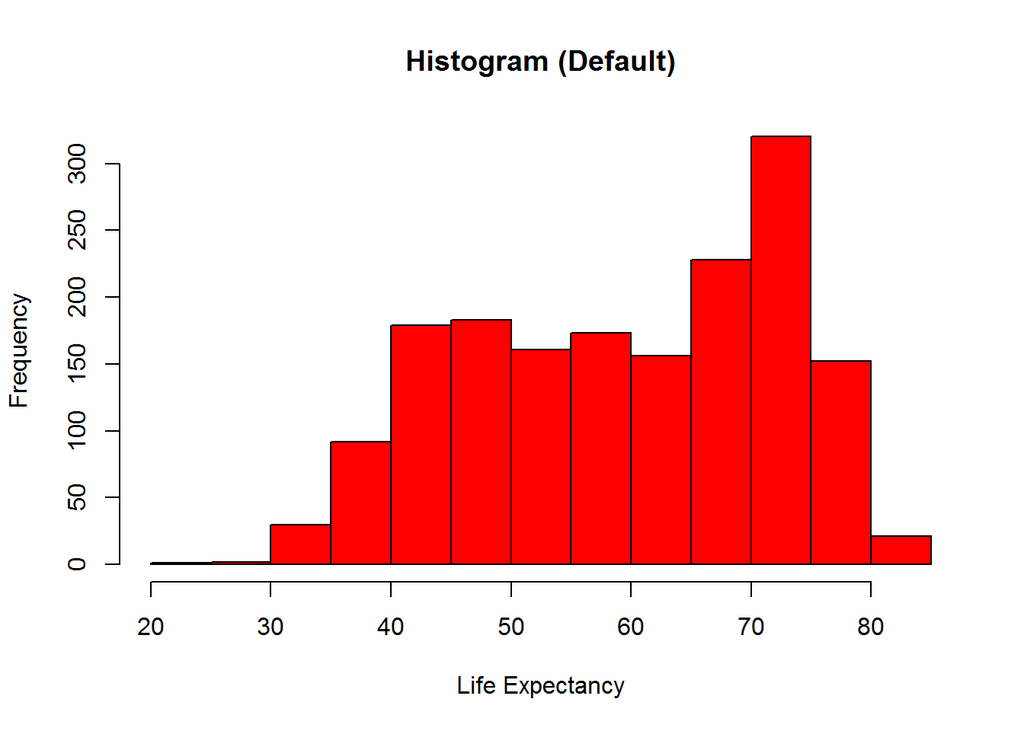

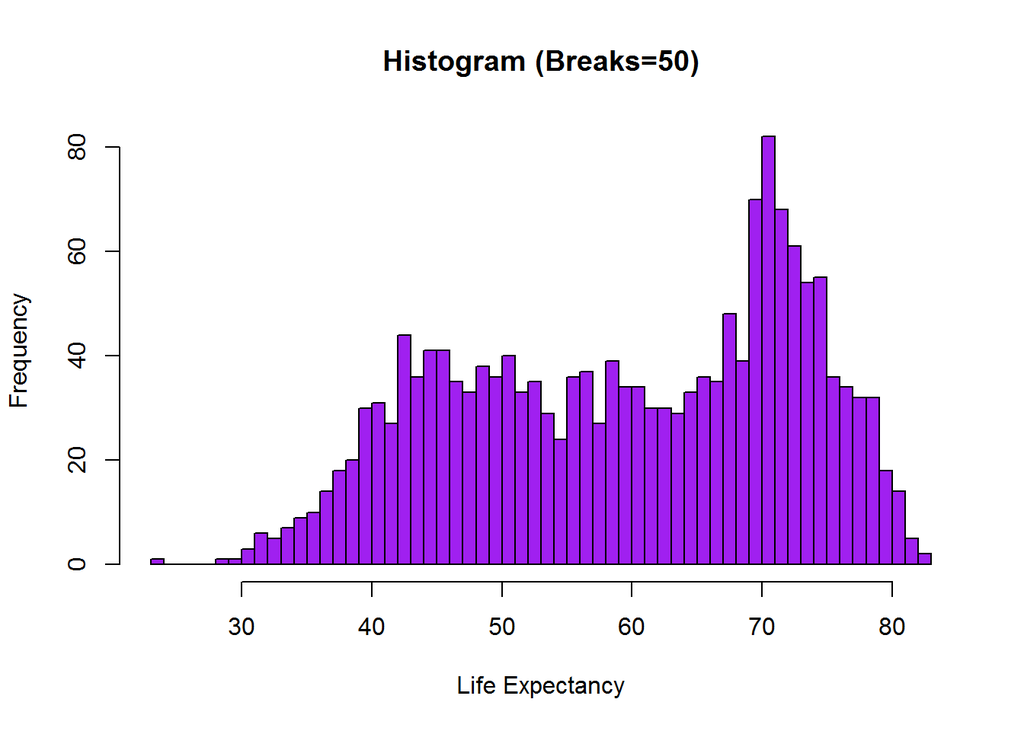

4. Compile the final Rmd file to html, make sure it looks ok, and then commit this html file as well (should be in your working directory) and push everything to github.